# Lighthouse Labs

## W4D5 - Introduction to Machine Learning (ML)

**Instructor:** Socorro E. Dominguez-Vidana

[figure not shown]

Overview:

- [] Machine Learning
  - [] Supervised vs. Unsupervised Learning
- [] Supervised Learning
  - [] `X` and `y`
  - [] Regression vs. Classification
  - [] The golden rule: train/test split
- [] Simple Linear Regression
- [] Polynomial Regression

## Machine Learning

#### What is Machine Learning (ML)?

- A subset of **A**rtificial **I**ntelligence.
- **ML** algorithms learn from data (training data) to make predictions or decisions without explicit programming.
- Models are built based on sample data to adapt and improve over time.

  > “The field of study that gives computers the ability to learn without being explicitly programmed.” — Arthur Samuel (1959)

[figure not shown]

### Types of Machine Learning

#### Supervised Learning

- Involves training models using labeled data, where the correct output is known. The algorithm learns to map inputs (*X*) to the desired outputs (*y*)

[figure not shown]

[Author unknown. (n.d.). Supervised vs Unsupervised Machine Learning Medium.](https://cdn-images-1.medium.com/max/1600/1*Iz7bCLrPTImnBDOOEyE3LA.png)

#### Unsupervised Learning

- Works with unlabeled data, where the algorithm explores patterns and structures within the data **without** knowing the correct answers.

[figure not shown]

[Author unknown. (n.d.). Data Science vs. Machine Learning Medium.](https://cdn-images-1.medium.com/max/1440/1*YUl_BcqFPgX49sSb5yrk3A.jpeg)

### Supervised Learning: Regression & Classification

#### Classification Problems

- Classification is about assigning items to specific categories or groups, also called classes.
- The goal is to predict which class an input belongs to, based on patterns in the data.
  - *Binary Classification*: Involves two possible outcomes.
    - Predicting whether a patient has liver disease or not.
  - *Multi-class Classification*: Involves more than two classes.
    - Predicting a student’s letter grade (A, B, C, D, or F).
- Real-world applications:
  - Spam detection in emails (classify as spam or not spam).
  - Image recognition (classify objects or people in a photo).
  - Sentiment analysis (classify text as positive, negative, or neutral).

#### Regression Problems

- Regression is used when the task is to predict a continuous value rather than a discrete category.
- The goal is to model the relationship between the input variables and the output to make numerical predictions.
  - *Linear Regression*: The relationship between **input** features and the **predicted value** is modeled as a straight line.
    - Predicting house prices based on features like square footage, number of bedrooms, or location.
  - *Non-linear Regression*: The relationship is more complex and doesn’t follow a straight line.
    - Predicting the growth of a population over time.
- Real-world applications:
  - Forecasting stock prices based on historical data.
  - Predicting the amount of rainfall based on weather conditions like temperature and humidity.

[figure not shown]

Mukherjee, A. (n.d.). AI Part 3: Regression vs Classification Models. LinkedIn

### The Golden Rule of Supervised Learning

- Once you've identified your features (**X**) and target (**y**), it's crucial to **split your data** into two sets: *training* and *testing*.
- You should only work with the **training data** when building your model.
  - If you involve test data in your decision-making (e.g., selecting or dropping features), you're allowing the test set to influence your choices.
  - This can cause **data leakage**, meaning your model has been indirectly exposed to the test data.
  - As a result, your model's performance won't reflect how it would perform on **unseen data** in real-world scenarios.

By keeping the test data **untouched**, your evaluation will be more reliable and representative of how the model generalizes to new data.

### Training vs. Test Scores

- When evaluating a model, we typically look at two scores: **training score** vs. **test score**.
- The **test score** is more important because it reflects how the model performs on unseen data.
- **Good models** that generalize well will have **similar training and test scores**.
- Our goal is to choose models that can **generalize well** to new, unseen data, not just memorize the training data.

#### The fundamental tradeoff

| Model | Training Score relative to Test Score | Performance |
| --- | --- | --- |
| Too Complex | High training score compared to test score | Overfit |
| Too Simple | Low training score and low test score | Underfit |

- Models that have **extremely high training scores** ahd have learned **highly complex** relationships in the training data can be **overfit**
- On the other hand, models that have **low training scores** and are **very simple** may not have learned the necessary relationships in the training data needed to predict well on unseen data; they are **underfit**

[figure not shown]

[Sahu, P. (2020, September 9). Techniques for handling underfitting and overfitting in machine learning. Towards Data Science.](https://towardsdatascience.com/techniques-for-handling-underfitting-and-overfitting-in-machine-learning-348daa2380b9)

#### Empirical Risk Minimization (ERM)

- In ML we aim to minimize the **empirical risk** (the average loss over training data).
- The goal is to approximate the best possible model by minimizing the loss function on the training set.
- However, errors can occur at different stages of the learning process.

### Three Main Errors

#### Approximation Error

- This error occurs when the model is **too simple** to capture the true underlying function.
- It represents the gap between the **best possible model** and the true function.
- Example: Using a linear model to fit a highly non-linear function.
- To minimize error (future lectures):
  - Use more **complex models** with higher capacity.
  - Apply **feature engineering** to capture more relevant information.

#### Estimation Error

- This error arises from the fact that we only have a **finite sample** of data.
- The model learned on the training data may not generalize well to unseen data.
- Small training data or sampling noise.
- Overfitting to the training data, leading to poor performance on unseen data.
- To minimize error (future lectures):
  - Increase the **size of the training dataset**.
  - Use **regularization techniques** to prevent overfitting.
  - Cross-validation for better model selection.

#### Optimization Error

- This error occurs when the algorithm fails to find the **global minimum** of the loss function during training.
- This can happen when the optimization process gets stuck in local minima or saddle points.
- To minimize error (future lectures):
  - Use more effective **optimization algorithms** (e.g., `Adam`, `RMSprop`).
  - Tune `hyperparameters` carefully.

#### Fundamental Trade-off

- Minimizing **approximation error** helps ensure that our model generalizes well to unseen data.

$$E_{approx} = (E_{test} - E_{train})$$

- There is often a **trade-off** between model complexity and test error:
  - A more complex model can fit the **specific patterns** in the training data, increasing $E_{approx}$.
  - This can lead to **overfitting**, where the model doesn't generalize well to new data.
- As model complexity increases, $E_{approx}$ tends to grow, making it harder for the model to generalize.
- However, **more data** can reduce $E_{approx}$ and improve generalization.

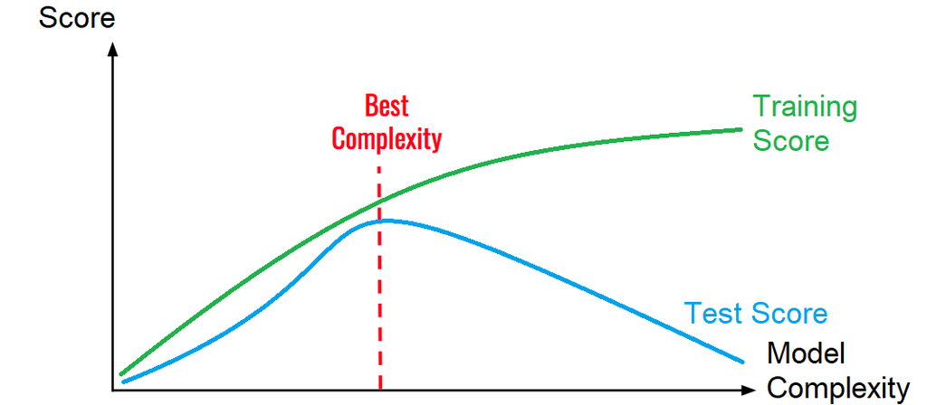

### Bias-Variance Trade-off

- **Bias error**: Error due to **incorrect assumptions** in the learning model.
  - High bias leads to **underfitting** (the model fails to capture key patterns).
- **Variance**: Error due to the model's **sensitivity** to small fluctuations in training data.
  - High variance leads to **overfitting** (the model captures noise instead of the true signal).
- **Key balance**: The goal is to find the right balance between bias and variance for a model that generalizes well.

[figure not shown]

[Cornell University. (2018). Lecture 12: Bias/Variance Tradeoff. Cornell University CS4780: Machine Learning.](https://www.cs.cornell.edu/courses/cs4780/2018fa/lectures/lecturenote12.html)

## Linear Regression

- Linear regression is one of the most basic and popular ML/statistical techniques.
- Used as a predictive model
- Assumes a linear relationship between the dependent variable (which is the variable we are trying to predict/estimate, **y**) and the independent variable/s (input variable/s used in the prediction, **X**)

## Simple Linear Regression

- Only one independent/input variable is used to predict the dependent variable.

$$\hat{y} = wx + b$$

$\hat{y}$ = Dependent variable

$b$ = Constant

$w$ = Coefficients

$x$ = Independent variable

## Multiple Linear Regression

- Many $x$'s and $w$'s

$$\hat{y} = w_1x_1 + w_2x_2 + ... + b$$

- The larger the value of $w_i$, the more influence $x_i$ has on the target $\hat{y}$